# The Anatomy of a Plot

## What & Why?

## What is it

- An R wrapper for the beloved JavaScript Highcharts library
- Pretty and versatile: bars, maps, bubbles, heatmaps, density, timeseries, and so on
- Interactive: many plots in one
- syntactically similar to ggplot2

## Why you’ll like it

- Same reasons: pretty, versatile, interactive, not even hard.
- Interactive plots *save you time*.

###### No more labeling bar heights

###### Include context without clutter via hover box

###### No more plotting every combination of comparison groups (simply click to show/hide groups)

###### Allow for x and y zooms (especially useful for timeseries)

- People will respect you
- *You get to use R*

## We cannot let the python bros win.

## But seriously…

- highcharter *makes R look good*. **Dress your data to impress.**
- We *all* benefit when you make R look good.

###### Your company will keep hiring R users (they don’t see the code, they see the output)

###### More people will want to learn R

- People expect fancy viz now.

###### The world is digital (don’t make print plots for digital viewing)

###### Gamification, leader boards, etc. raised viz expectations for non-tech people

- You can justify R in a sea of Python users

###### You can use my line: “R is for research, Python is for production.”

- Again, we cannot let the python bros win.

###### If we lose the viz battle I’m becoming an interior decorator.

## Highcharter: from + to %>%

A guided tour

## Basics

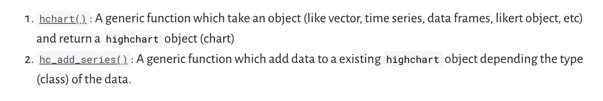

## Basics

[figure not shown]

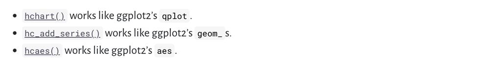